# Plotting tools

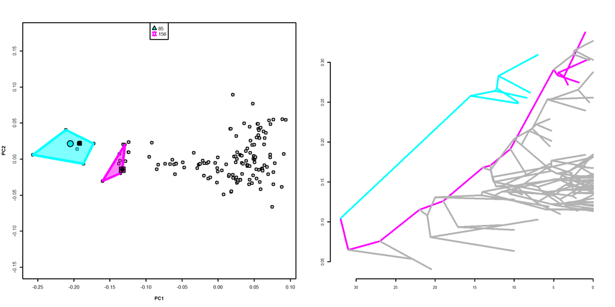

```r
plotSC$plotPChull(chull.args = list(border=c("cyan","magenta"),lty=1),
              means.args = list(pch=c(21,22),cex=3,bg=c("cyan2","magenta2")),
              ace.args=list(pch=c(7,10)),legend.args = list(pch=c(24,11),bty="o",x="top"))
plotSC$plotTraitgram(colTree = "gray70",colNodes = c("cyan","magenta"),yaxt="s")
```

When convergence between states is tested, `plotConv` returns two functions. Similarly to the ‘clade case’, `plotPChull` generates a PC1/PC2 plot (obtained by performing a PCA of the species phenotypes) with different states enclosed by colored convex hulls. The plot is entirely customizable by setting the arguments `plot.args`,`chull.args`, `points.args`, and `legend.args`. If the state vector includes a background state (“nostate”), the polygon for such category is always the first to be plotted, so that the first `border` color or `lty` in `chull.args` is attributed to “nostate” (see the example below for clarification). The function `plotPolar` generates a polar plot showing the mean angle within/between state/s contrasted to the 95% confidence interval of angles derived by randomization (see search.conv for further details). The circular plot area can be customized by providing a list of `polar.args` to `plotPolar`. The lines for the mean angle and the polygon for its 95% CI can be modified by setting the arguments `line.args` (arguments passed to `polar.plot` under `rp.type="r"`) and `polygon.args` (arguments passed to `polar.plot` under `rp.type="p"`), respectively.

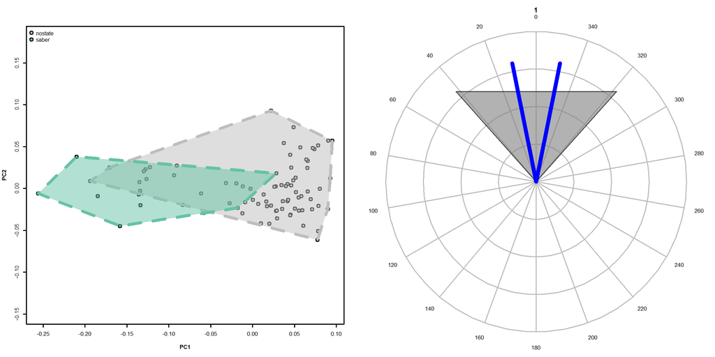

```r
# Perform search.conv within "saber" category
search.conv(tree=treefel, y=PCscoresfel, state=statefel,declust=TRUE,clus=cc)->sc_state

## Visualize search.conv results
# variable = 1 must be indicated also when a single row is output
plotConv(SC=sc_state, y=PCscoresfel, variable=1, state=statefel)->plotSC_state

# Using default options
plotSC_state$plotPChull()
plotSC_state$plotPolar()
```

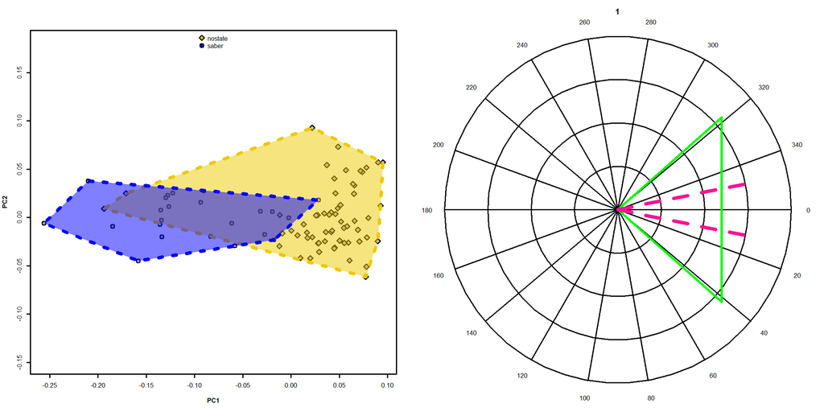

```r
## Customizing parameters
plotSC_state$plotPChull(chull.args=list(border=c("gold2","blue"),lty=3),
             points.args=list(pch=c(23,21),bg="gray"),
             legend.args=list(pch=c(23,21),x="top"))

plotSC_state$plotPolar(polar.args=list(clockwise=TRUE,start=0,rad.col="black",grid.col="black"),
            polygon.args=list(line.col="green",poly.col=NA,lwd=2),
            line.args=list(line.col="deeppink",lty=2,lwd=3))
```